# Final tables

## Instruction Notebook

The notebook allows the user to construct to different level of aggregation:

- `industry`
- `geocode4_corr` -> city

By default, the `aggregation_param` parameter is set to `industry`. To switch to city, change for `geocode4_corr`. Then launch the notebook for new results

In the paper, we define a threshold to distinguish cities or industries. Choose among this set of threshold:

- 5
- 6
- 7
- 8
- mean

By default, the `threshold_full` parameter is set to `6`. To switch to another threshold, change the threshold `threshold_full`. Then launch the notebook for new results

[output not shown]

# Load Data

## Compute Herfhindal: proxy Size

$$ H=\sum_{i=1}^{N} s_{i}^{2} $$

where $s_i$ is the market share of industry[city] $i$ in a city [industry], and $N$ is the number of firms.

We proceed as follow:

- Step 1: Compute the share [output, capital, employment] by city-industry: `market_share_cit`
- Step 2: compute the sum of squared market share by industry[city]: `Herfindahl_agg_t`
- Step 3: Compute the average across time: `Herfindahl_agg`
- Step 4: Compute the deciles of step 3: `decile_herfhindal_agg`
  - Low decile implies a low concentration within sectors
  - High decile implies a high concentration within sectors

## Compute Ownership: proxy Foreign/SOE

$$\sum output_{agg,o}/ \sum output_{agg}$$

- with $agg$ stands for industry[city]
- $o$ stands for ownership (Foreign vs Domestic or SOE vs private)

### Foreign vs domestic

We proceed as follow:

- Step 1: Compute the share [output, capital, employment] by industry[city], ownership (Foreign/Domestic): `Share_X_agg_o`
- ~Step 2: Compute dummy when share Foreign above share domestic by industry[city]~
- Step 3: Compute decile by industry[city]-ownership
  - Note, high decile in Foreign means the industry[city] has relatively high share of foreign output, but not in absolule value as in step 2. A decile 9 in foreign can be a decile 2 or 3 in Domestic

### SOE vs Private

We proceed as follow:

- Step 1: Compute the share [output, capital, employment] by industry[city], ownership (SOE/PRIVATE): `Share_X_agg_o`
- ~Step 2: Compute dummy when share SOE above share domestic by industry[city]~
- Step 3: Compute decile by industry[city]-ownership
  - Note, high decile in SOE means the industry[city] has relatively high share of SOE output, but not in absolule value as in step 2. A decile 9 in SOE can be a decile 2 or 3 in Domestic

## Load TCZ_list_china from Google Spreadsheet

Feel free to add description about the dataset or any usefull information.

Profiling will be available soon for this dataset

## Load chinese_city_characteristics from Google Spreadsheet

Feel free to add description about the dataset or any usefull information.

Profiling will be available soon for this dataset

## Create R tables

INFO: NumExpr defaulting to 8 threads.

# Table 3

1. Full sample

$$ Log SO2 emission _{i k t}=\alpha\left(\text { Period } \times \text { Target }_{i} \times \text { Polluting sectors }_{k} \right)+\nu_{i}+\lambda_{t}+\phi_{k}+\epsilon_{i k t} $$$$ Log SO2 emission _{i k t}=\alpha\left(\text { Period } \times \text { Target }_{i} \times \text { Polluting sectors }_{k} \right)+\nu_{ct}+\lambda_{kt}+\phi_{ck}+\epsilon_{i k t} $$

1. TRUE

2. TRUE

3. TRUE

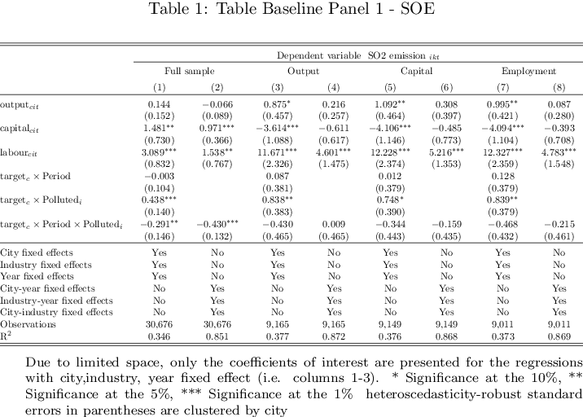

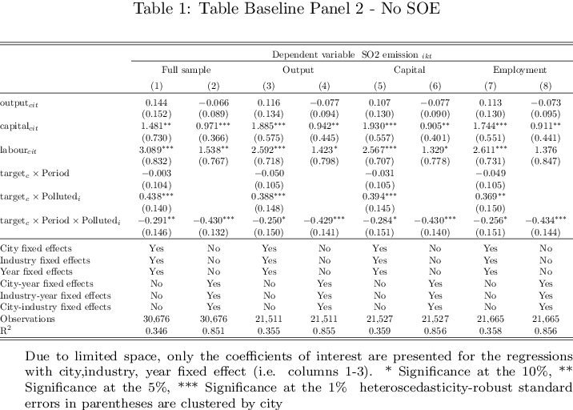

# Table 4 parallel trend

$$ \begin{aligned} \log \mathrm{SO} 2 \text { emission }_{i k t}=\sum_{t=2002}^{2007} \alpha\left(Target_{i} \times\right.& \text { Polluting sectors }\left._{k} \times y e a r_{t}\right) \\ &+\theta X_{i k t}+\nu_{i k}+\lambda_{i t}+\phi_{k t}+\epsilon_{i k t} \end{aligned} $$

1. Full sample
2. SOE dominated vs No SOE dominated
   - output
   - capital
   - employment

1. TRUE

2. TRUE

3. TRUE

4. TRUE

5. TRUE

6. TRUE

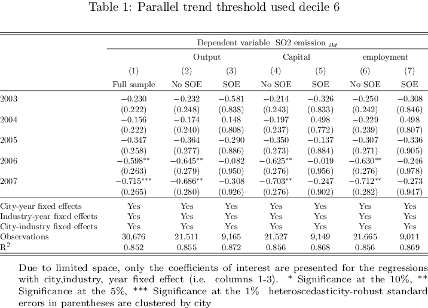

# Diffusion chanels

- TCZ VS non TCZ
- Concentrated VS non concentrated
- Kuznet
  - TCZ
  - Concentration
  - SOE
- TFP

## TCZ VS non TCZ

1. TRUE

2. TRUE

3. TRUE

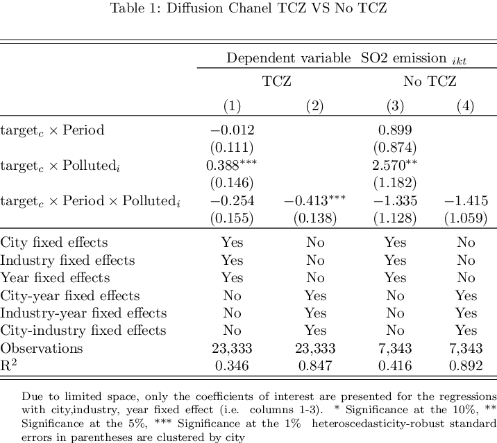

## Concentrated VS non concentrated

1. TRUE

2. TRUE

3. TRUE

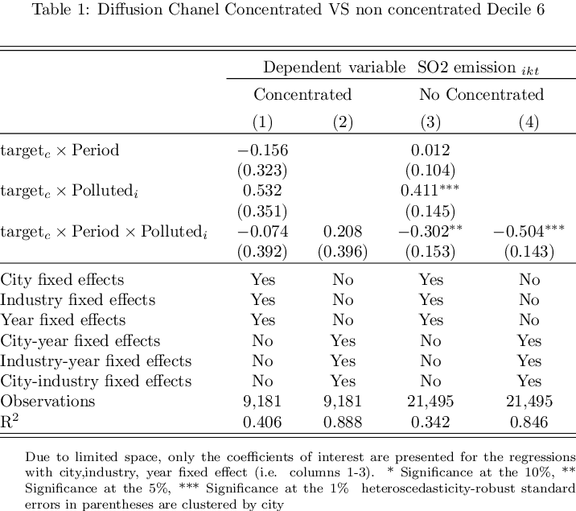

## Kuznet

Estimate the following model

$$ Log SO2 emission _{i k t}=\alpha\left(\text { Period } \times \text { Target }{i} \times \text { Polluting sectors }{k} \right)+Kuznet+\nu{i}+\lambda_{t}+\phi_{k}+\epsilon_{i k t} $$$$ Log SO2 emission _{i k t}=\alpha\left(\text { Period } \times \text { Target }{i} \times \text { Polluting sectors }{k} \right)+Kuznet+\nu_{ct}+\lambda_{kt}+\phi_{ck}+\epsilon_{i k t} $$

1. TCZ vs No TCZ
2. Concentrated vs No Concentrated
3. SOE vs No SOE
   - output
   - capital
   - employment

1. TRUE

2. TRUE

3. TRUE

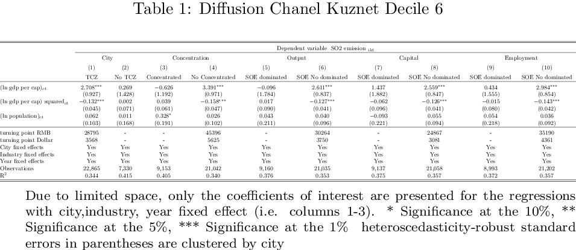

## TFP

$$ TFP _{i k t}=\alpha\left(\text { Period } \times \text { Target }{i} \times \text { Polluting sectors }{k} \right)+\nu{i}+\lambda_{t}+\phi_{k}+\epsilon_{i k t} $$$$ TFP _{i k t}=\alpha\left(\text { Period } \times \text { Target }{i} \times \text { Polluting sectors }{k} \right)+\nu_{ct}+\lambda_{kt}+\phi_{ck}+\epsilon_{i k t} $$